# EDA project:R语言对红酒各因素进行探索性分析

### 挥发酸和柠檬酸在不同质量下的相关关系:

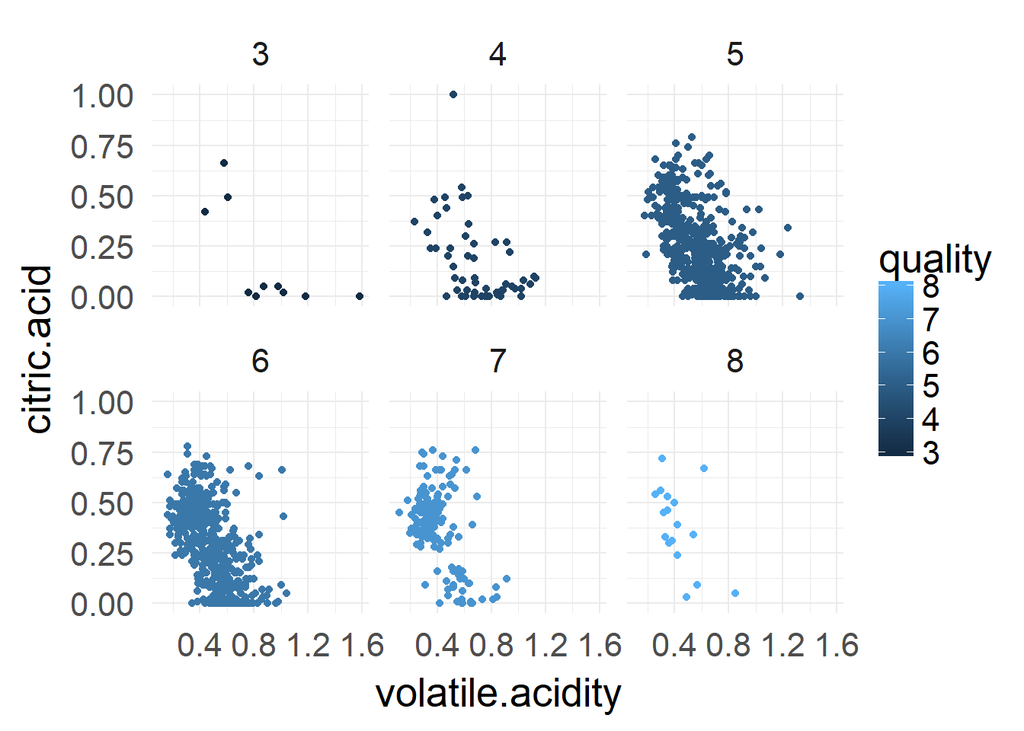

从上面的图中可以看出，在挥发酸一定的情况下，不论酒的质量如何，它们的柠檬酸含量范围都差不多，可见柠檬酸对红酒质量影响不大，但是该图也再一次确认了质量越高的红酒，其挥发酸含量越少。

### 硫化物和总二氧化硫在不同质量下的相关关系:

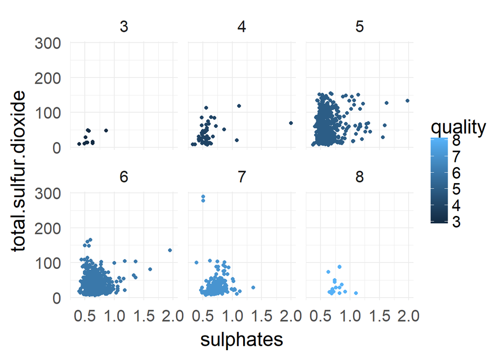

### 酒精和密度在不同质量下的相关关系图

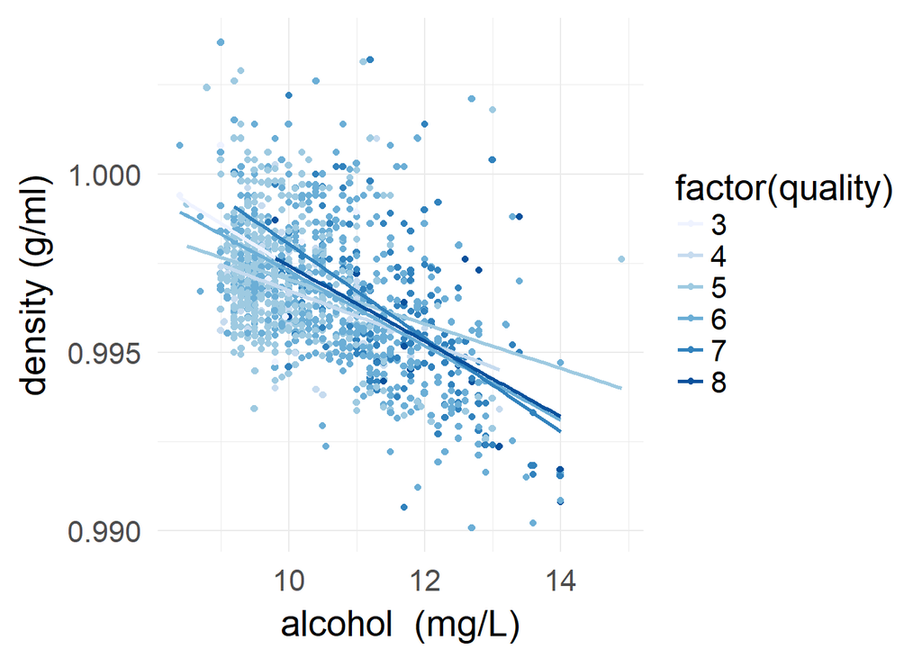

从上图中不难发现，红酒的酒精度和密度有很强的相关性，而且对于不同质量的红酒都是如此。即：随着酒精浓度增加，红酒的密度逐渐下降。

### 多变量分析小结

1. 探讨你在这部分探究中观察到的一些关系,通过观察感兴趣的特性,是否存在相互促进的特性?

高品质红酒多集中在挥发酸低的区域。

质量较好的红酒主要分布在挥发性酸较低和固定酸较高的区域，而质量较差的红酒则更多集中在固定酸较低和挥发性酸较高的区域。

柠檬酸对红酒质量影响不大。

不管是什么质量的红酒，都满足：随着酒精浓度增加，红酒的密度逐渐下降。

# 5.最终成图和汇总

## 图一

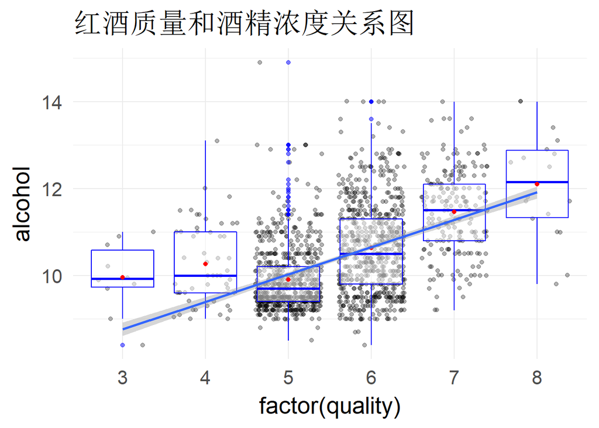

从图一我们可以发现，酒精浓度越高往往对应的红酒质量越高。

## 图二

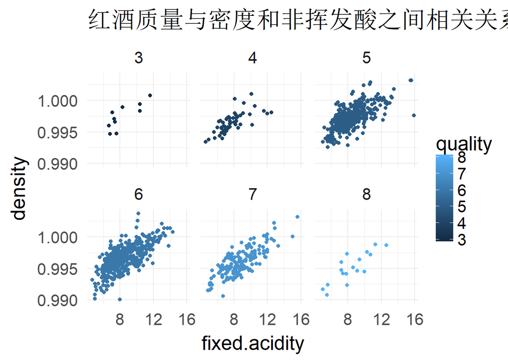

从图二中发现，对于不同质量的红酒，几乎都满足随着非挥发性酸的浓度提高，红酒的密度不断提高的特点。

## 图三

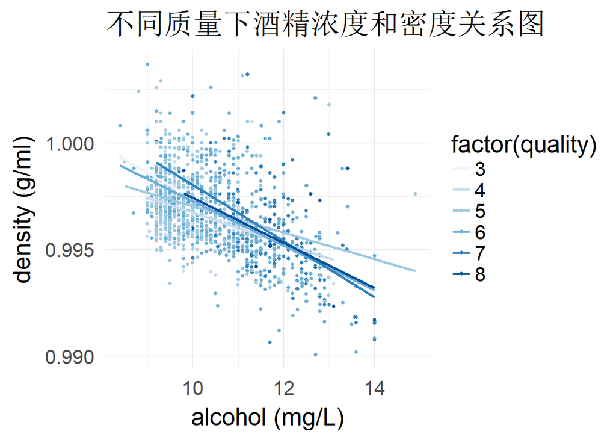

分析发现不同质量的红酒都满足随着酒精浓度增加，红酒的密度逐渐下降的规律。

# 6.反思

我的整个分析过程主要围绕红酒质量和与他相关度较高的几个变量进行分析，分析过程中也分析了一些其他的变量。

我在探索过程中始终发现不了什么具体的其他因素对红酒质量有强烈的影响，没有发现相关性极高的两个或者多个变量，这一度使我觉得十分沮丧。后来我想也许探索性数据分析不应过分关注细节，应该从多考虑考虑均值等因素的变化趋势，我一下子变得豁然开朗。数据在处理过程中总要有所舍弃，我不能力求分析所有数据，只能尽可能考虑总体趋势。

红酒数据集的样本量还是不够大，未来，如果有更大的样本，我想分析的结果一定更加精确可信。讲来也可以引入机器学习算法来构建一些合理的预测模型。